# The magick package: Advanced Image-Processing in R

2026-02-28

The magick package provide a modern and simple toolkit for image processing in R. It wraps the [ImageMagick STL](https://imagemagick.org/Magick++/STL.html) which is the most comprehensive open-source image processing library available today.

The ImageMagick library has an overwhelming amount of functionality. Magick exposes a decent subset of it, but it is impossible to document everything in detail. This article introduces some basic concepts and examples to get started.

## Installing `magick`

On Windows or macOS the package is most easily installed via CRAN.

```r
install.packages("magick")
```

The binary CRAN packages work out of the box and have most important features enabled. Use `magick_config` to see which features and formats are supported by your version of ImageMagick.

```r
library(magick)
str(magick::magick_config())
```

```
## List of 24
##  $ version           :Class 'numeric_version'  hidden list of 1
##   ..$ : int [1:4] 6 9 13 29
##  $ modules           : logi FALSE
##  $ cairo             : logi TRUE
##  $ fontconfig        : logi TRUE
##  $ freetype          : logi TRUE
##  $ fftw              : logi FALSE
##  $ ghostscript       : logi FALSE
##  $ heic              : logi TRUE
##  $ jpeg              : logi TRUE
##  $ lcms              : logi TRUE
##  $ libopenjp2        : logi TRUE
##  $ lzma              : logi TRUE
##  $ pangocairo        : logi TRUE
##  $ pango             : logi TRUE
##  $ png               : logi TRUE
##  $ raw               : logi TRUE
##  $ rsvg              : logi TRUE
##  $ tiff              : logi TRUE
##  $ webp              : logi TRUE
##  $ wmf               : logi FALSE
##  $ x11               : logi FALSE
##  $ xml               : logi TRUE
##  $ zero-configuration: logi TRUE
##  $ threads           : int 1
```

### Build from source

On Linux you need to install the ImageMagick++ library: on Debian/Ubuntu this is called libmagick++-dev:

```
sudo apt-get install libmagick++-dev
```

On Fedora or CentOS/RHEL we need [ImageMagick-c++-devel](https://src.fedoraproject.org/rpms/ImageMagick):

```
sudo yum install ImageMagick-c++-devel
```

To install from source on macOS you need either `imagemagick@6` or `imagemagick` from homebrew.

```
brew install imagemagick@6
```

Unfortunately the current `imagemagick@6` configuration on homebrew disables a bunch of features, including librsvg and fontconfig. Therefore the quality of fonts and svg rendering might be suboptimal. The is not a problem for the CRAN binary package.

## Image IO

What makes magick so magical is that it automatically converts and renders all common image formats. ImageMagick supports dozens of formats and automatically detects the type. Use `magick::magick_config()` to list the formats that your version of ImageMagick supports.

### Read and write

Images can be read directly from a file path, URL, or raw vector with image data with `image_read`. The `image_info` function shows some meta data about the image, similar to the imagemagick `identify` command line utility.

```
##   format width height colorspace matte filesize density
## 1    PNG   350    350       sRGB  TRUE        0   72x72
```

[figure not shown]

```r
library(magick)
tiger <- image_read_svg('http://jeroen.github.io/images/tiger.svg', width = 350)
print(tiger)
```

We use `image_write` to export an image in any format to a file on disk, or in memory if `path = NULL`.

```r
# Render svg to png bitmap
image_write(tiger, path = "tiger.png", format = "png")
```

If `path` is a filename, `image_write` returns `path` on success such that the result can be piped into function taking a file path.

### Converting formats

Magick keeps the image in memory in its original format. Specify the `format` parameter `image_write` to convert to another format. You can also internally convert the image to another format earlier, before applying transformations. This can be useful if your original format is lossy.

```r
tiger_png <- image_convert(tiger, "png")
image_info(tiger_png)
```

```
##   format width height colorspace matte filesize density
## 1    PNG   350    350       sRGB  TRUE        0   72x72
```

Note that size is currently 0 because ImageMagick is lazy (in the good sense) and does not render until it has to.

### Preview

IDE’s with a built-in web browser (such as RStudio) automatically display magick images in the viewer. This results in a neat interactive image editing environment.

[figure not shown]

Alternatively, on Linux you can use `image_display` to preview the image in an X11 window. Finally `image_browse` opens the image in your system’s default application for a given type.

```r
# X11 only
image_display(tiger)

# System dependent
image_browse(tiger)
```

Another method is converting the image to a raster object and plot it on R’s graphics display. However this is very slow and only useful in combination with other plotting functionality. See #raster below.

## Transformations

The best way to get a sense of available transformations is walk through the examples in the `?transformations` help page in RStudio. Below a few examples to get a sense of what is possible.

### Cut and edit

Several of the transformation functions take an `geometry` parameter which requires a special syntax of the form `AxB+C+D` where each element is optional. Some examples:

- `image_crop(image, "100x150+50")`: *crop out `width:100px` and `height:150px` starting `+50px` from the left*
- `image_scale(image, "200")`: *resize proportionally to width: `200px`*
- `image_scale(image, "x200")`: *resize proportionally to height: `200px`*
- `image_fill(image, "blue", "+100+200")`: *flood fill with blue starting at the point at `x:100, y:200`*
- `image_border(frink, "red", "20x10")`: *adds a border of 20px left+right and 10px top+bottom*

The full syntax is specified in the [Magick::Geometry](https://imagemagick.org/Magick++/Geometry.html) documentation.

```r
# Example image
frink <- image_read("https://jeroen.github.io/images/frink.png")
```

```r
print(frink)
```

```
##   format width height colorspace matte filesize density
## 1    PNG   220    445       sRGB  TRUE    73494   72x72
```

[figure not shown]

[figure not shown]

```r
# Add 20px left/right and 10px top/bottom
image_border(image_background(frink, "hotpink"), "#000080", "20x10")
```

[figure not shown]

```r
# Trim margins
image_trim(frink)
```

```r
# Passport pica
image_crop(frink, "100x150+50")
```

[output not shown]

[figure not shown]

```r
# Resize
image_scale(frink, "300") # width: 300px
```

[figure not shown]

```r
image_scale(frink, "x300") # height: 300px
```

[figure not shown]

```r
# Rotate or mirror
image_rotate(frink, 45)
```

[figure not shown]

```r
image_flip(frink)
```

[figure not shown]

```r
image_flop(frink)
```

[figure not shown]

```r
# Brightness, Saturation, Hue
image_modulate(frink, brightness = 80, saturation = 120, hue = 90)
```

[figure not shown]

```r
# Paint the shirt orange
image_fill(frink, "orange", point = "+100+200", fuzz = 20)
```

With `image_fill` we can flood fill starting at pixel `point`. The `fuzz` parameter allows for the fill to cross for adjacent pixels with similarish colors. Its value must be between 0 and 256^2 specifying the max geometric distance between colors to be considered equal. Here we give professor frink an orange shirt for the World Cup.

### Filters and effects

ImageMagick also has a bunch of standard effects that are worth checking out.

[figure not shown]

```r
# Add randomness
image_blur(frink, 10, 5)
```

[figure not shown]

```r
image_noise(frink)
```

[figure not shown]

```r
# Silly filters
image_charcoal(frink)
```

[figure not shown]

```r
image_oilpaint(frink)
```

[figure not shown]

```r
image_negate(frink)
```

### Kernel convolution

The `image_convolve()` function applies a kernel over the image. Kernel convolution means that each pixel value is recalculated using the weighted neighborhood sum defined in the kernel matrix. For example lets look at this simple kernel:

```r
kern <- matrix(0, ncol = 3, nrow = 3)
kern[1, 2] <- 0.25
kern[2, c(1, 3)] <- 0.25
kern[3, 2] <- 0.25
kern
```

```
##      [,1] [,2] [,3]
## [1,] 0.00 0.25 0.00
## [2,] 0.25 0.00 0.25
## [3,] 0.00 0.25 0.00
```

This kernel changes each pixel to the mean of its horizontal and vertical neighboring pixels, which results in a slight blurring effect in the right-hand image below:

[figure not shown]

```r
img <- image_resize(logo, "300x300")
img_blurred <- image_convolve(img, kern)
image_append(c(img, img_blurred))
```

Or use any of the [standard kernels](https://legacy.imagemagick.org/Usage/convolve/)

[figure not shown]

```r
img |> image_convolve('Sobel') |> image_negate()
```

[figure not shown]

```r
img |> image_convolve('DoG:0,0,2') |> image_negate()
```

### Text annotation

Finally it can be useful to print some text on top of images:

[figure not shown]

```r
# Add some text
image_annotate(frink, "I like R!", size = 70, gravity = "southwest", color = "green")
```

[figure not shown]

```r
# Customize text
image_annotate(frink, "CONFIDENTIAL", size = 30, color = "red", boxcolor = "pink",
  degrees = 60, location = "+50+100")
```

[figure not shown]

```r
# Fonts may require ImageMagick has fontconfig
image_annotate(frink, "The quick brown fox", font = 'Times', size = 30)
```

Fonts that are supported on most platforms include `"sans"`, `"mono"`, `"serif"`, `"Times"`, `"Helvetica"`, `"Trebuchet"`, `"Georgia"`, `"Palatino"`or `"Comic Sans"`.

### Combining with pipes

Each of the image transformation functions returns a **modified copy** of the original image. It does not affect the original image.

```r
frink <- image_read("https://jeroen.github.io/images/frink.png")
frink2 <- image_scale(frink, "100")
image_info(frink)
```

```
##   format width height colorspace matte filesize density
## 1    PNG   220    445       sRGB  TRUE    73494   72x72
```

```r
image_info(frink2)
```

```
##   format width height colorspace matte filesize density
## 1    PNG   100    202       sRGB  TRUE        0   72x72
```

Hence to combine transformations you need to chain them:

```
##   format width height colorspace matte filesize density
## 1    PNG   465    240       sRGB  TRUE        0   72x72
```

[figure not shown]

```r
test <- image_rotate(frink, 90)
test <- image_background(test, "blue", flatten = TRUE)
test <- image_border(test, "red", "10x10")
test <- image_annotate(test, "This is how we combine transformations", color = "white", size = 30)
print(test)
```

[figure not shown]

```r
image_read("https://jeroen.github.io/images/frink.png") |>
  image_rotate(270) |>
  image_background("blue", flatten = TRUE) |>
  image_border("red", "10x10") |>
  image_annotate("The same thing with pipes", color = "white", size = 30)
```

## Image Vectors

The examples above concern single images. However all functions in magick have been vectorized to support working with layers, compositions or animation.

The standard base methods `[` `[[`, `c()` and `length()` are used to manipulate vectors of images which can then be treated as layers or frames.

```r
# Download earth gif and make it a bit smaller for vignette
earth <- image_read("https://jeroen.github.io/images/earth.gif") |>
  image_scale("200x") |>
  image_quantize(128)

length(earth)
```

```
## [1] 44
```

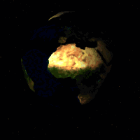

```r
earth
```

```r
head(image_info(earth))
```

```
##   format width height colorspace matte filesize density
## 1    GIF   200    200        RGB FALSE        0   72x72
## 2    GIF   200    200        RGB  TRUE        0   72x72
## 3    GIF   200    200        RGB  TRUE        0   72x72
## 4    GIF   200    200        RGB  TRUE        0   72x72
## 5    GIF   200    200        RGB  TRUE        0   72x72
## 6    GIF   200    200        RGB  TRUE        0   72x72
```

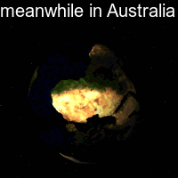

```r
rev(earth) |>
  image_flip() |>
  image_annotate("meanwhile in Australia", size = 20, color = "white")
```

### Layers

We can stack layers on top of each other as we would in Photoshop:

```r
bigdata <- image_read('https://jeroen.github.io/images/bigdata.jpg')
frink <- image_read("https://jeroen.github.io/images/frink.png")
logo <- image_read("https://jeroen.github.io/images/Rlogo.png")
img <- c(bigdata, logo, frink)
img <- image_scale(img, "300x300")
image_info(img)
```

```
##   format width height colorspace matte filesize density
## 1   JPEG   300    225       sRGB FALSE        0   72x72
## 2    PNG   300    232       sRGB  TRUE        0   72x72
## 3    PNG   148    300       sRGB  TRUE        0   72x72
```

A mosaic prints images on top of one another, expanding the output canvas such that that everything fits:

[figure not shown]

```r
image_mosaic(img)
```

Flattening combines the layers into a single image which has the size of the first image:

[figure not shown]

```r
image_flatten(img)
```

Flattening and mosaic allow for specifying alternative [composite operators](https://imagemagick.org/Magick++/Enumerations.html):

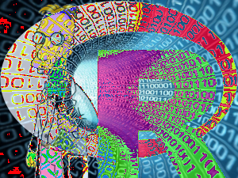

```r
image_flatten(img, 'Add')
```

[figure not shown]

```r
image_flatten(img, 'Modulate')
```

[figure not shown]

```r
image_flatten(img, 'Minus')
```